# Reproductible Research

# Peer-graded Assignment: Course Project 1 by ISMAIL HASSAN DJILAL

## Introduction

It is now possible to collect a large amount of data about personal movement using activity monitoring devices such as a Fitbit, Nike Fuelband, or Jawbone Up. These type of devices are part of the “quantified self” movement - a group of enthusiasts who take measurements about themselves regularly to improve their health, to find patterns in their behavior, or because they are tech geeks. But these data remain under-utilized both because the raw data are hard to obtain and there is a lack of statistical methods and software for processing and interpreting the data.

This assignment makes use of data from a personal activity monitoring device. This device collects data at 5 minute intervals through out the day. The data consists of two months of data from an anonymous individual collected during the months of October and November, 2012 and include the number of steps taken in 5 minute intervals each day. The data for this assignment can be downloaded from the course web site:

Dataset: [Activity monitoring data](https://d396qusza40orc.cloudfront.net/repdata%2Fdata%2Factivity.zip) [52K]

The variables included in this dataset are:

- **steps**: Number of steps taking in a 5-minute interval (missing values are coded as NA)
- **date**: The date on which the measurement was taken in YYYY-MM-DD format
- **interval**: Identifier for the 5-minute interval in which measurement was taken

## Loading and preprocessing the data

```r
data1<-read.csv(file="activity.csv",head=TRUE,sep=",")
data1$date<-as.Date(data1$date,format="%Y-%m-%d")
head(data1,10)
```

```
##    steps       date interval
## 1     NA 2012-10-01        0
## 2     NA 2012-10-01        5
## 3     NA 2012-10-01       10
## 4     NA 2012-10-01       15
## 5     NA 2012-10-01       20
## 6     NA 2012-10-01       25
## 7     NA 2012-10-01       30
## 8     NA 2012-10-01       35
## 9     NA 2012-10-01       40
## 10    NA 2012-10-01       45
```

```r
library(dplyr)
data1 %>%select(steps, date) %>% group_by(date) %>%summarise(total=sum(steps,na.rm=TRUE))
```

```
## # A tibble: 61 x 2
##          date total
##        <date> <int>
##  1 2012-10-01     0
##  2 2012-10-02   126
##  3 2012-10-03 11352
##  4 2012-10-04 12116
##  5 2012-10-05 13294
##  6 2012-10-06 15420
##  7 2012-10-07 11015
##  8 2012-10-08     0
##  9 2012-10-09 12811
## 10 2012-10-10  9900
## # ... with 51 more rows
```

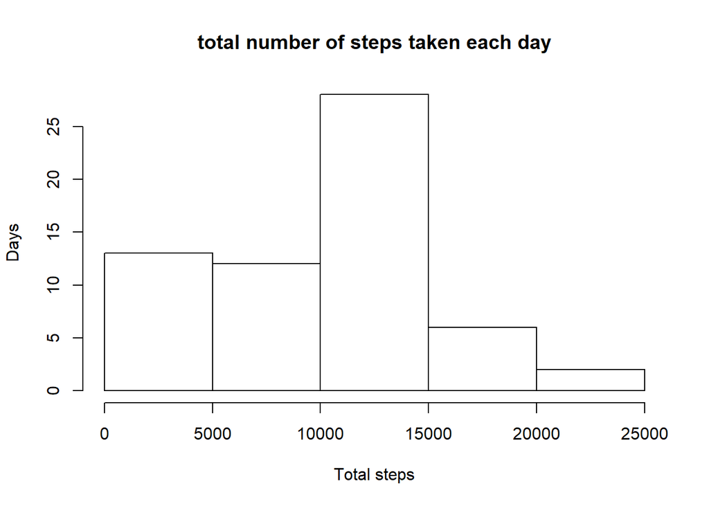

```r
data1 %>%select(steps, date) %>% group_by(date) %>%summarise(total=sum(steps,na.rm=TRUE))%>%with(hist(total, main="total number of steps taken each day", xlab="Total steps", ylab="Days"))
```

3.

```r
data1 %>%select(steps, date) %>% group_by(date) %>%summarise(total=sum(steps,na.rm=TRUE),mean=mean(steps,na.rm=TRUE),median=median(steps,na.rm=TRUE))
```

```
## # A tibble: 61 x 4
##          date total     mean median
##        <date> <int>    <dbl>  <dbl>
##  1 2012-10-01     0      NaN     NA
##  2 2012-10-02   126  0.43750      0
##  3 2012-10-03 11352 39.41667      0
##  4 2012-10-04 12116 42.06944      0
##  5 2012-10-05 13294 46.15972      0
##  6 2012-10-06 15420 53.54167      0
##  7 2012-10-07 11015 38.24653      0
##  8 2012-10-08     0      NaN     NA
##  9 2012-10-09 12811 44.48264      0
## 10 2012-10-10  9900 34.37500      0
## # ... with 51 more rows
```

## What is the average daily activity pattern?

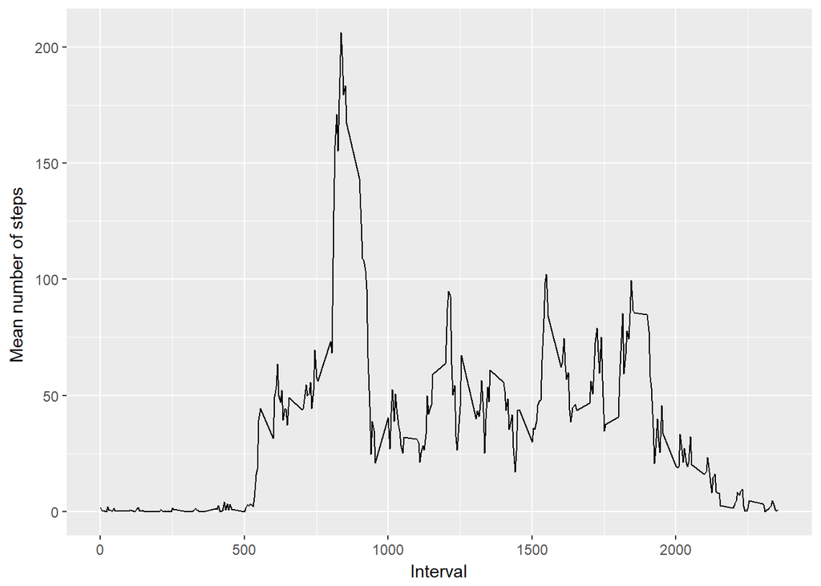

```r
library(ggplot2)
data1 %>% select(steps,interval)%>%group_by(interval) %>%summarise(mean=mean(steps,na.rm=TRUE))%>%ggplot(aes(x = interval, y = mean)) + geom_line()+ xlab("Interval")+ ylab("Mean number of steps ")
```

```r
data1 %>% select(steps,interval)%>%group_by(interval) %>%summarise(mean=mean(steps,na.rm=TRUE))%>%arrange(desc(mean))%>%head(1)
```

```
## # A tibble: 1 x 2
##   interval     mean
##      <int>    <dbl>
## 1      835 206.1698
```

The maximum average steps taken interval is 835 to 840 minutes interval, which taken the 206.1698 stpes in that 5 minute interval.

## Imputing missing values

1.count missing values `

```r
sum(is.na(data1))
```

```
## [1] 2304
```

2.filling missing values

```r
datafill<-data1
for(i in 1:ncol(datafill)){
  datafill[is.na(datafill[,i]), i] <- mean(datafill[,i], na.rm = TRUE)
}
head(datafill)
```

```
##     steps       date interval
## 1 37.3826 2012-10-01        0
## 2 37.3826 2012-10-01        5
## 3 37.3826 2012-10-01       10
## 4 37.3826 2012-10-01       15
## 5 37.3826 2012-10-01       20
## 6 37.3826 2012-10-01       25
```

```r
head(datafill)
```

```
##     steps       date interval
## 1 37.3826 2012-10-01        0
## 2 37.3826 2012-10-01        5
## 3 37.3826 2012-10-01       10
## 4 37.3826 2012-10-01       15
## 5 37.3826 2012-10-01       20
## 6 37.3826 2012-10-01       25
```

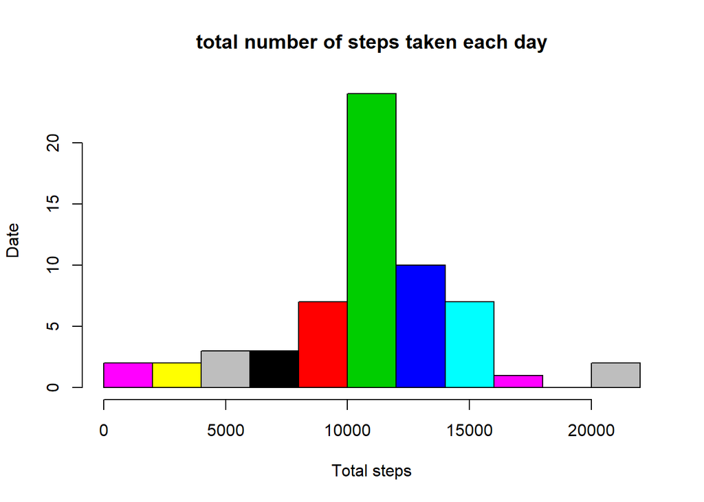

```r
datafill %>%select(steps, date) %>% group_by(date) %>%summarise(total=sum(steps,na.rm=TRUE))%>%with(hist(total,10, col=date,main="total number of steps taken each day", xlab="Total steps", ylab="Date"))
```

```r
datafill %>%select(steps, date) %>% group_by(date) %>%summarise(total=sum(steps,na.rm=TRUE),mean=mean(steps,na.rm=TRUE),median=median(steps,na.rm=TRUE))
```

```
## # A tibble: 61 x 4
##          date    total     mean  median
##        <date>    <dbl>    <dbl>   <dbl>
##  1 2012-10-01 10766.19 37.38260 37.3826
##  2 2012-10-02   126.00  0.43750  0.0000
##  3 2012-10-03 11352.00 39.41667  0.0000
##  4 2012-10-04 12116.00 42.06944  0.0000
##  5 2012-10-05 13294.00 46.15972  0.0000
##  6 2012-10-06 15420.00 53.54167  0.0000
##  7 2012-10-07 11015.00 38.24653  0.0000
##  8 2012-10-08 10766.19 37.38260 37.3826
##  9 2012-10-09 12811.00 44.48264  0.0000
## 10 2012-10-10  9900.00 34.37500  0.0000
## # ... with 51 more rows
```

## Are there differences in activity patterns between weekdays and weekends?

```r
library(timeDate)
datafill$date <- as.Date(datafill$date)

datafill$weekend<-ifelse(isWeekday(datafill$date, wday=1:5), "Weekdays", "Weekend")
```

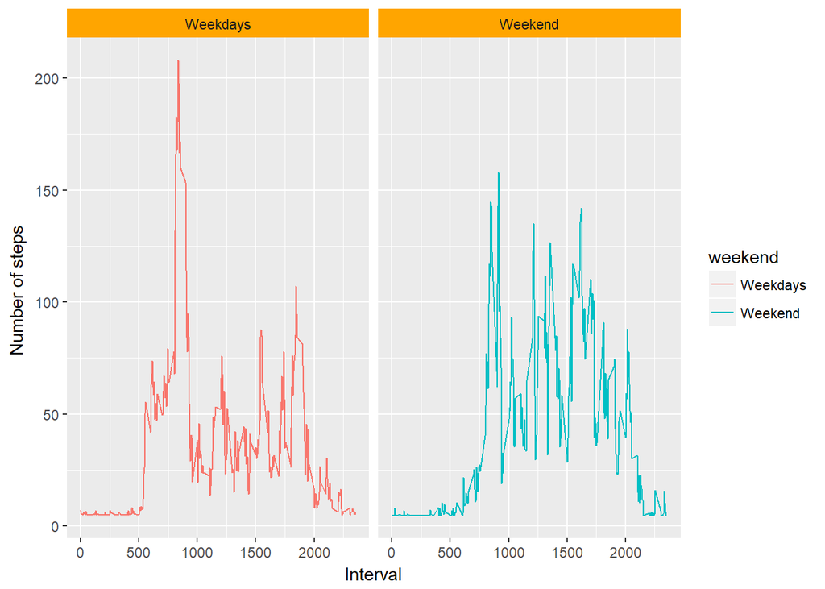

```r
library(ggplot2)
datafill %>% select(steps,interval,weekend)%>%group_by(weekend, interval) %>%summarise(mean=mean(steps,na.rm=TRUE))%>%ggplot(aes(x = interval, y = mean,colour=weekend)) + geom_line(aes(colour=weekend))+ xlab("Interval")+ ylab("Number of steps ")+facet_wrap(~weekend)+theme(strip.background = element_rect(fill="orange"))
```